## 데이터 전처리 근거

*전처리 근거에 가장 중요한 요소는 바로 위치이다, 우리는 승객들이 머무는 위치인 Deck에 따른*  
*Transported의비율이 서로 차이가 심하다는 점에서 승객들이 머무는 위치가 종속변수를 예측하는데 가장 중요한* *요소라고 생각했다*

# *1*

HomePlanet 과 Destination 은 각각 3가지의 목적지,출발지를 갖고 있다. 변수를 하나로 줄이면 해석하기 더 쉽고 정보의 손실이 없으므로 두 변수를 9가지 범주를 갖는 하나의 변수로 묶었다.

Home Destination 에 따른 Transported 차이는 큼 그이유는 목적지 출발지에 따라 사람들이 머무는 Deck이 정해져 있어서임. 그렇다면 이 변수가 Deck 이랑 겹치니까 삭제할수있지 않냐고 생각할수 있지만 출발지마다 3~4개의 Deck이 정해져 있고 그중 랜덤이라 삭제 불가.

[figure not shown]

# *2*

Name 이라는 변수 이외에도 우리는 PassengerId를 통해서 승객을 구분할수 있다. 따라서 Name은 삭제한다.

# *3*

```
##        Transported
##         False True
##   FALSE  3613 1833
##   TRUE    702 2545
```

# *4*

Cabin이라는 변수는 그안에 Deck, Side, Number 총 3가지의 변수를 갖고 있다. ggplot을 통해 각 변수와 Transported의 연관성을 보았는데 number는 *같은* Deck안에 있는 사람들의 번호이므로 불필요하다고 생각하고 제거했다. 하지만 Deck과 Side는 변수간 Transported된 비율이 차이가 있으므로 냅둔다.

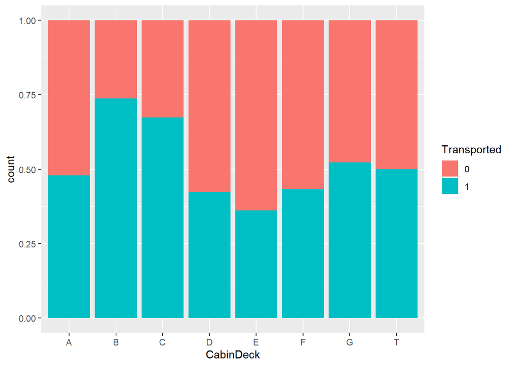

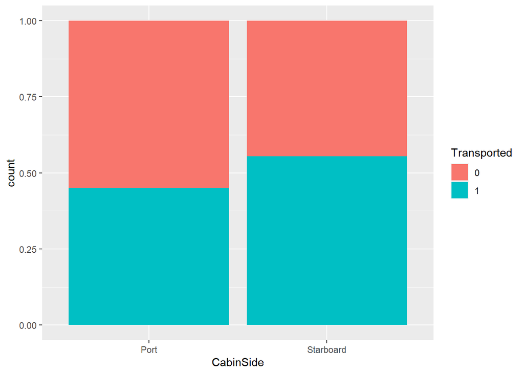

# *5*

CryoSleep 유무의 따라 Transported 된 비율이 차이가 크게 있어 유의미한 변수라 생각하고 냅둔다.

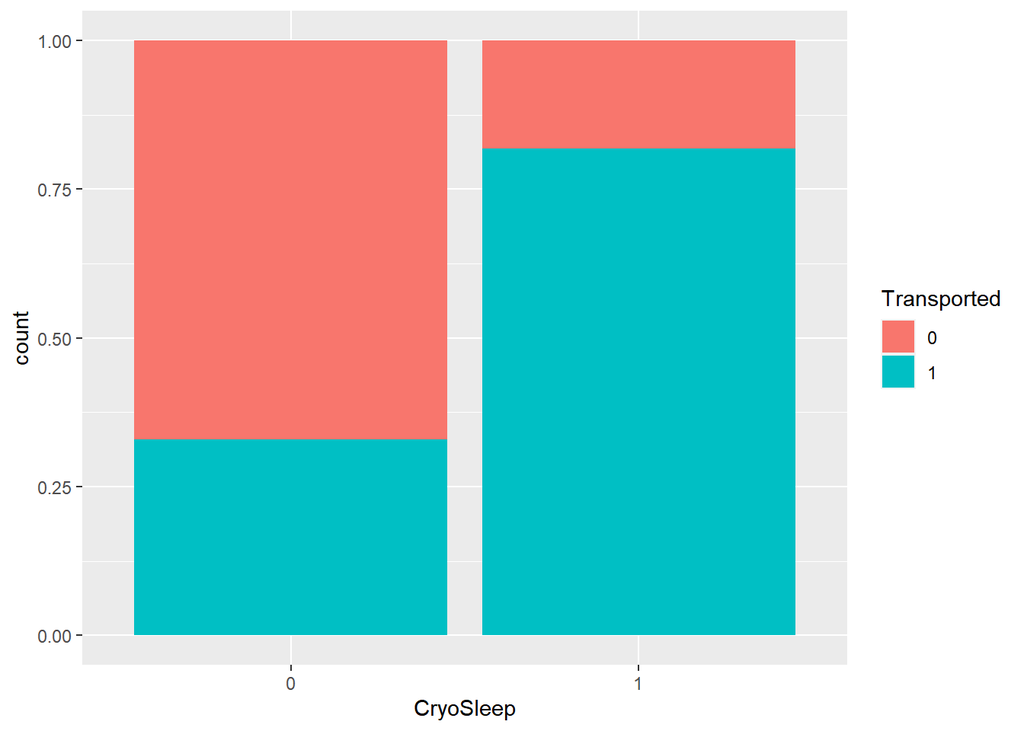

# *6*

나이는 아직 논의중. 하지만 나이별 transported 비율을 확인했을때 10세이후에는 별차이가 없지만 10세 이전에는 75% 정도 이동함, 이는 몸이 약한 아이들이더 Transported 된 비율이 높다는것을 보여줌.

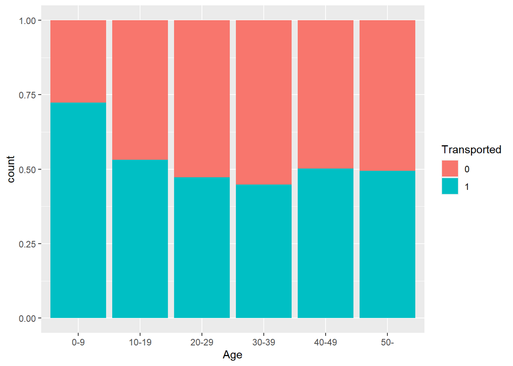

# *7*

VIP인 경우에는 오히려 Transported 된 비율이 낮음, VIP를 제거하고 분석할까 고민했지만 Transported 된 비율 차이가 10% 이상 나서 일단 변수로 사용함

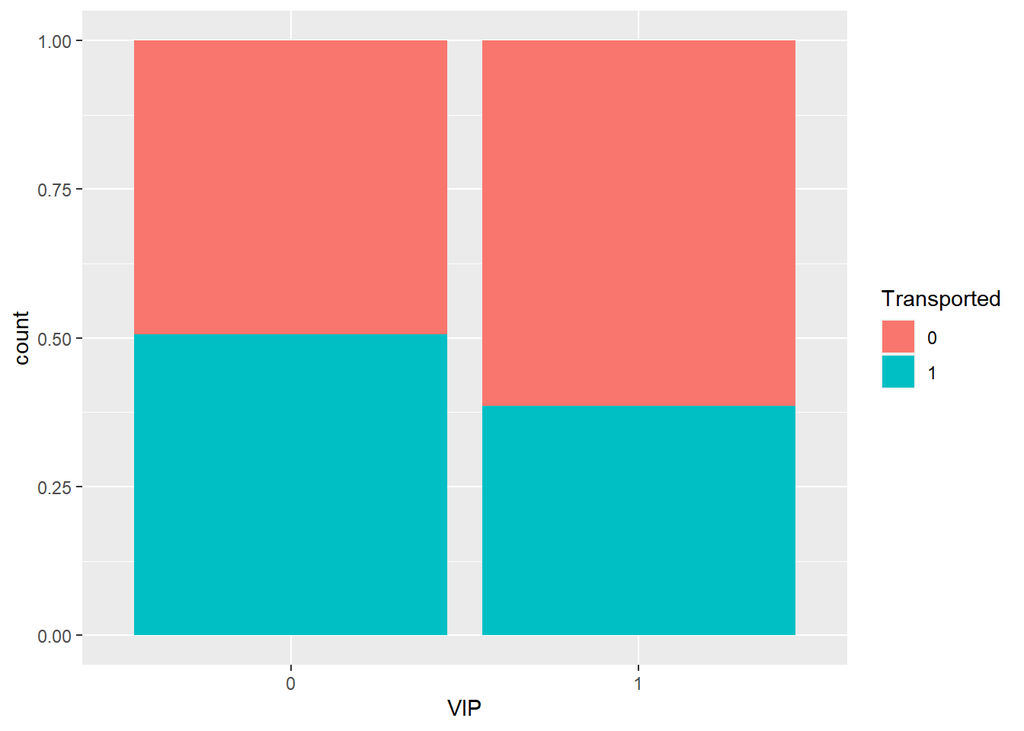

# 최종 데이터

```
##   PassengerId CryoSleep   Age VIP Service CabinDeck CabinSide
## 1     0001_01         0 30-39   0       0         B      Port
## 2     0002_01         0 20-29   0     736         F Starboard
## 3     0003_01         0   50-   1   10383         A Starboard
## 4     0003_02         0 30-39   0    5176         A Starboard
## 5     0004_01         0 10-19   0    1091         F Starboard
## 6     0005_01         0 40-49   0     774         F      Port
##      Home_Destination Transported
## 1  Europa-TRAPPIST-1e           0
## 2   Earth-TRAPPIST-1e           1
## 3  Europa-TRAPPIST-1e           0
## 4  Europa-TRAPPIST-1e           0
## 5   Earth-TRAPPIST-1e           1
## 6 Earth-PSO J318.5-22           1
```